# A5: Incarceration

### Introduction

The U.S. prison system starkly illustrates systemic racism, with over-policing and the war on drugs disproportionately impacting people of color. This study analyzes various datasets to uncover trends and disparities in incarceration. The datasets include prison populations per county/state, incarceration rates per 100,000 people, and historical data starting from 1990 in Washington State. By comparing these variables, we can identify regions with high incarceration rates and track changes over time. A specific focus on Washington State allows for detailed analysis of state-level policies. This comprehensive approach aims to highlight racial inequities and inform criminal justice reform discussions.

### The Dataset

**Who collected the data?** This data was collected by the Vera Institute.

**How was the data collected or generated?** The data was collected from two Bureau of Justice Statistics (BJS) collections: the Census of Jails (COJ), conducted every five to eight years since 1970, and the Annual Survey of Jails (ASJ), conducted since 1982, covering about one-third of jails.

**Why was the data collected?** The data was collected to provide insights into the growth and disparities within American jails, facilitating a better understanding of incarceration trends across the United States.

**How many observations (rows) are in your data?**

Dataset about prison population per county/state: 153811

Dataset about prison/jail population per 100,000 people (rate) per county/state: 153811

Smaller dataset about prison/jail population per 100,000 people (rate) per county/state starting at 1990 in Washington: 1131

**How many features (columns) are in the data?**

Dataset about prison population per county/state: 36

Dataset about prison/jail population per 100,000 people (rate) per county/state: 23

Smaller dataset about prison/jail population per 100,000 people (rate) per county/state starting at 1990 in Washington: 23

**What, if any, ethical questions or questions of power do you need to consider when working with this data?**

When working with datasets on prison and jail populations, ethical considerations arise regarding privacy, biases, and power dynamics. Maintaining individuals’ privacy and confidentiality is crucial, as is addressing inherent biases that may skew the data. Additionally, researchers must be mindful of the potential impact their findings may have on communities affected by mass incarceration and strive to present the data responsibly.

**What are possible limitations or problems with this data? (at least 200 words)**

When working with data on prison and jail populations, several limitations and potential problems must be considered. Firstly, the accuracy of the data heavily depends on the reporting practices of correctional facilities and agencies, which may lead to underreporting or incomplete reporting due to administrative errors or resource constraints. Moreover, differences in data collection methodologies across jurisdictions can introduce inconsistencies, making comparisons challenging and potentially compromising the reliability and validity of the dataset. Additionally, demographic information such as race, ethnicity, and gender may be inaccurately recorded or missing, obscuring disparities in incarceration rates among different demographic groups and limiting intersectional analyses. Furthermore, there may be a temporal lag in data availability, especially for historical datasets or periodic surveys, hindering timely analyses and the identification of emerging trends or policy impacts. Geographic disparities within regions, contextual factors influencing incarceration rates, and the limitations of rate calculations further complicate the interpretation of the data. Lastly, the dataset may not adequately capture the impact of policy changes, interventions, or criminal justice reforms enacted during the data collection period, necessitating careful consideration and contextual understanding when interpreting findings.

### Trends Over Time Chart

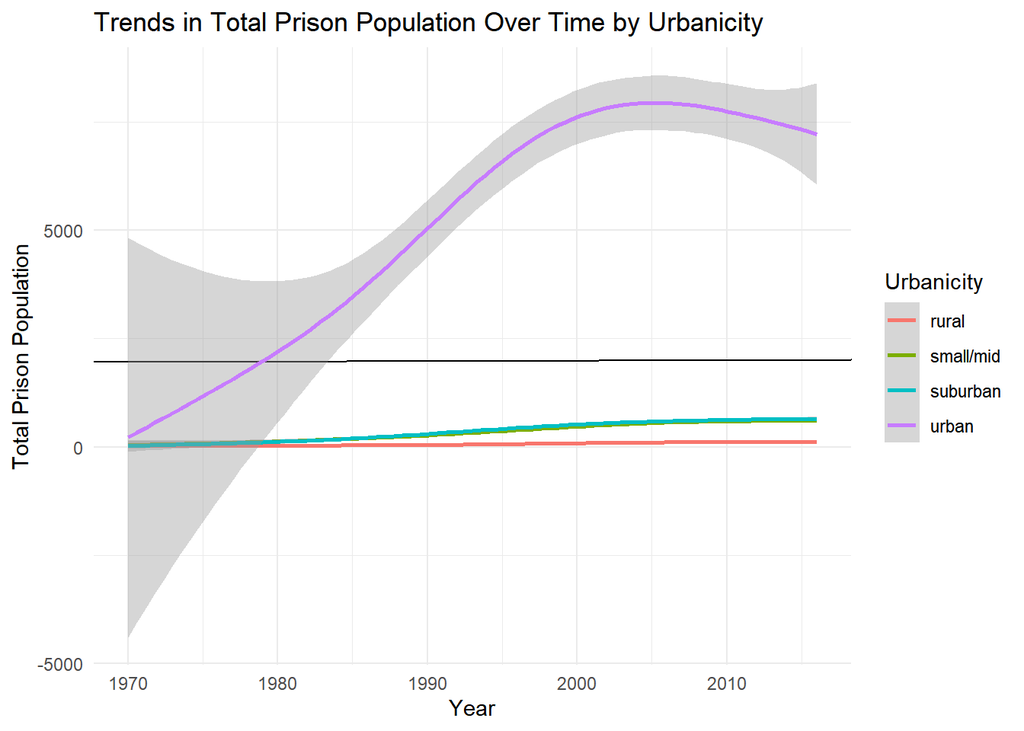

### Variable Comparison Chart

[output not shown]

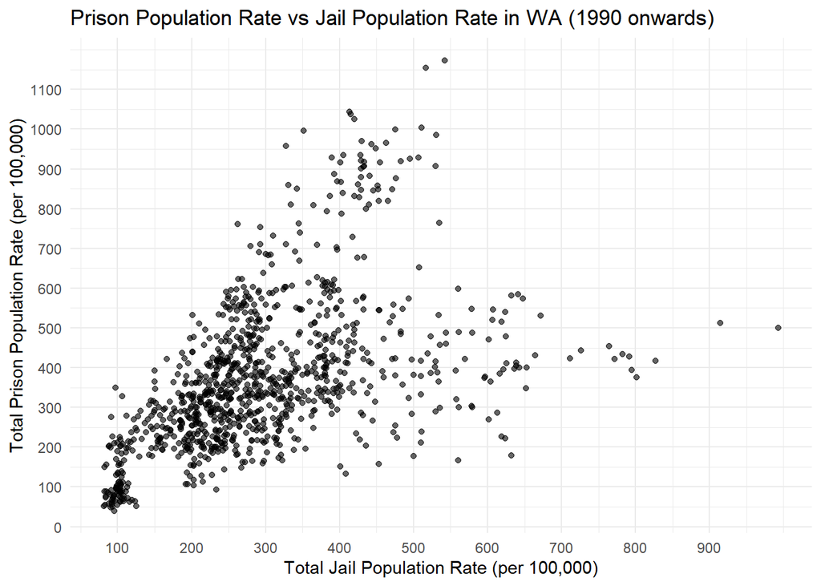

The scatter plot illustrates the relationship between the total prison population rate and the total jail population rate in Washington state from 1990 onwards. This visualization helps in understanding how changes in one rate might be associated with changes in the other, providing insights into broader trends in incarceration rates within the state.

### Map

```
## [1]   23849076 1497671767
```

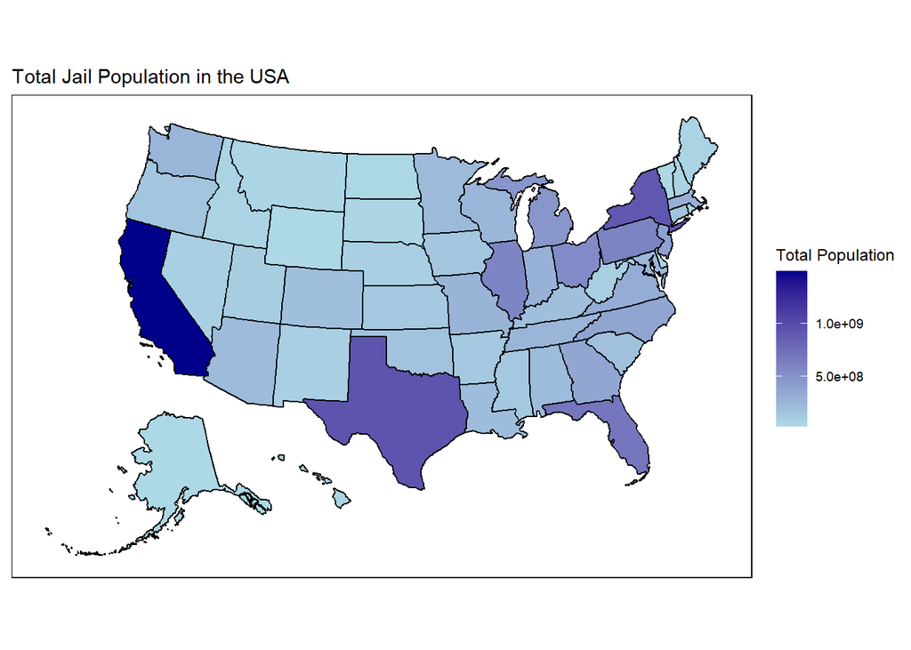